# 19-2-Distributions

2025-02-24

### Code Accompanying *The Machine Learning Handbooks*, Volume I, Chapters 8 and 19

#### Book pdf is available on the GitHub repo: https://github.com/kjmazidi/Machine_Learning_3rd_edition

### Introduction

This notebook explores some data distributions that are commonly found in machine learning. The code in this notebook corresponds to the data distribution discussion found in Chapter 8, Section 4.

Package imported in this notebook:

- MCMCpack for the Dirichlet distribution

```r
if (!require("MCMCpack")){
  install.packages("MCMCpack")
}
library(MCMCpack)
```

## Data distributions

Next we explore some of the most common of data distributions:

- normal
- binomial
- multinomial

### Normal distribution aka Gaussian distribution

Plotting a histogram of a quantitative variable shows how well the data fits a normal curve, or how skewed or random it may be.

The Gaussian or normal distribution is used for quantitative variables. Two parameters define its shape: the mean $\mu$ and the variance $\sigma^2$. The probability density function is:

$$\begin{equation}
f(x) = \frac{1}{\sqrt{2\pi\sigma}} exp\bigg( -\frac{(x -
\mu)^2}{2\sigma^2} \bigg)
\end{equation}$$

Let’s plot a few Gaussians to see how the mean and variance influence the shape. All 3 distributions are generated with the dnorm() function, and all have a mean of 0. Different means would shift the curves right or left. The three curves have different standard deviations.

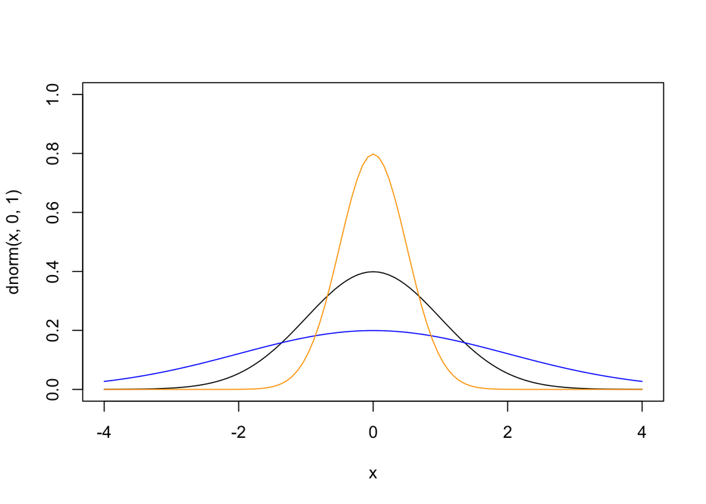

```r
curve( dnorm(x,0,1), xlim=c(-4,4), ylim=c(0,1) )
curve( dnorm(x,0,2), add=T, col='blue' )
curve( dnorm(x,0,.5), add=T, col='orange' )
```

The rnorm() function in R generates random numbers, following a normal distribution. The d in the dnorm() function is for density, as in pdf, probability density function. The dnorm() function returns the pdf for the normal distribution specified by the parameters.

$$\begin{equation}
f(x) = \frac{1}{\sqrt[D/2]{2\pi} \sqrt{\vert \Sigma \vert}} exp\bigg(
-\frac{(x - \mu)^T(x - \mu)}{2\Sigma} \bigg)
\end{equation}$$

### Binomial distributiion

These distributions concern binary variables representing such things as the flip of a coin, wins and losses, and so forth. Our example will be shooting baskets for practice, where x=1 means that we made a basket and x=0 means that we missed. Let’s say that I am shooting hoops for the first time and I made 2 baskets out of 10 tries. Given this data, my probability of making a basket is 0.2. The Bernoulli distribution describes binary outcomes like this example. The Bernoulli distribution has a parameter, $\mu$, which specifies the average probability of the positive class.

$$\begin{equation}
Bernoulli(x|\mu) = \mu^x(1-\mu)^{1-x}
\end{equation}$$

This gives us the probability that x is 1: $p(x=1) = 0.2^1 * .8^0 = 0.2$. And the probability that x is 0: $p(x=0) = 0.2^0 * .8^1 = 0.8$.

The Bernoulli distribution is a special case of the binomial distribution in which the number of trials, N = 1. Now suppose we run our Bernoulli trial N=100 times, that is, I shoot 100 baskets. Let X be the random variable which represents the number of baskets made. The binomial distribution of X where I made k baskets in N trials has the following probability mass function (pmf):

$$\begin{equation}
Binomial(k|N,\mu) = \bigg(\frac{N}{k}\bigg)\ \mu^k(1-\mu)^{N-k}
\end{equation}$$

Let’s let k=20 for our 100 trials. Will the outcome of the binomial be 0.2?

$$\begin{equation}
Binomial(20|100,0.2) = \bigg(\frac{100}{20}\bigg)\ 0.2^{20}(1-0.2)^{80}
= 0.09930021
\end{equation}$$

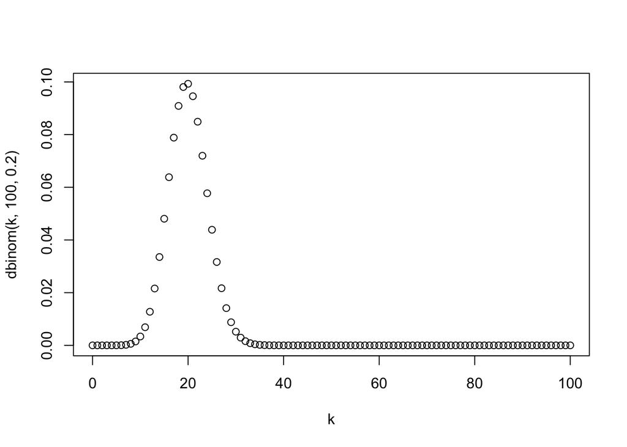

```r
k <- 0:100  # possible number of baskets for 100 tries
E <- sum(k * dbinom(k, 100, 0.2))
v <- 100 * .2 * .8
plot(k, dbinom(k, 100, 0.2))
```

$$\begin{equation}
Beta(\mu|a,b) =
\frac{\Gamma(a+b)}{\Gamma(a)\Gamma(b)}\mu^{a-1}(1-\mu)^{b-1}
\end{equation}$$

In the above equation, the first term with the gammas serves as a normalizing constant to make sure that the total probability integrates to 1. The gamma function is commonly used in probability, and is an extension of the factorial function to the real numbers: $\Gamma(n) = (n-1)!$ and is also extended to complex numbers. The parameters a and b in our example will be the number of baskets made and missed, respectively. Beta distributions are commonly used in Bayesian approaches to represent prior knowledge of a parameter. The gamma function is defined as follows for positive real numbers or complex numbers with a positive real portion:

$$\begin{equation}
\Gamma(x) \equiv \int_{0}^{\infty} u^{x-1}e^{-u}du
\end{equation}$$

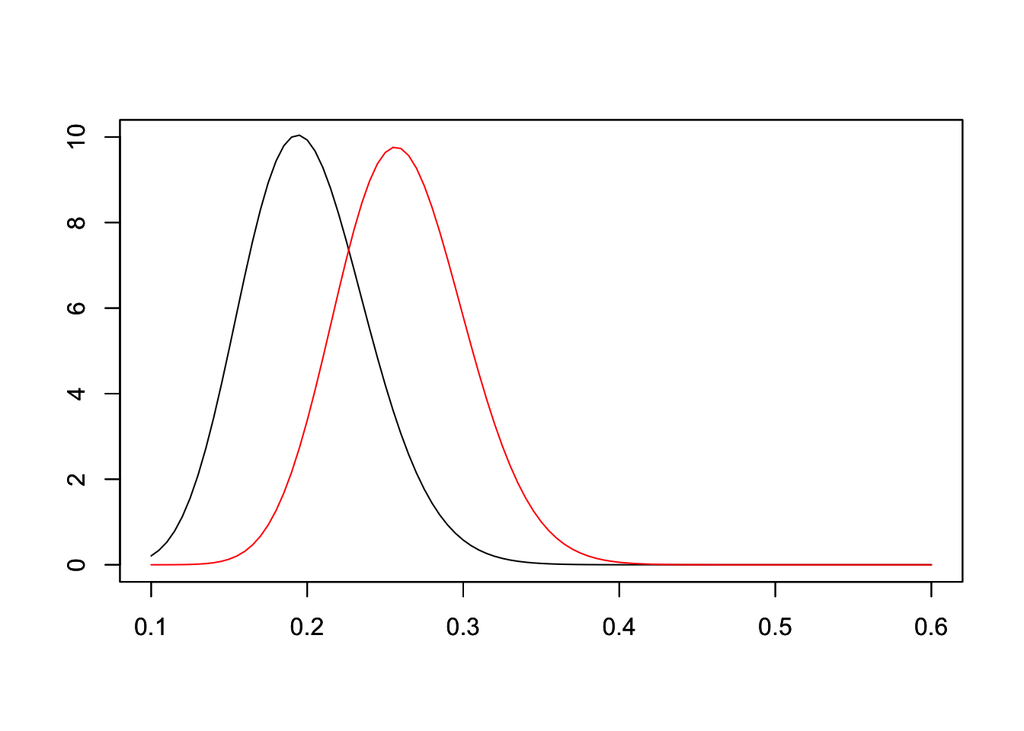

```r
x <- rbeta(100, 20, 80)
curve(dbeta(x, 20, 80), xlab=" ", ylab=" ", xlim=c(0.1,0.6),
     ylim=c(0,10))
par(new=TRUE)
curve(dbeta(x, 30, 85), xlab=" ", ylab=" ", xlim=c(0.1,0.6),
    ylim=c(0,10), col="red")
```

In the code and plot above, we updated the original black curve by adding baskets to a and misses to b. Our new probability given our data will be:

$$\begin{equation}
p(x=1|D) = \frac{a + m}{a + b + m + l}
\end{equation}$$

where m represents the number of new baskets and l represents the number of new losses.

The equation above is a Bayesian estimate. In contrast, note that the MLE estimate is simply $m/N$. As m and l approach infinity, the Bayesian estimate converges to the MLE. For a finite data set, the posterior probability with be between the prior and the MLE.

### Multinomial distribution

We can extend the binomial distribution to the case where we have variables that are not binary but can take on more than 2 values. This is a multinomial distribution. The probability mass function of a multinomial distribution is: %
$$\begin{equation}
Multinomial(m_1,m_2,...,m_k|N,\mu) =
\bigg(\frac{N}{m_1!m_2!...m_k!}\bigg) \prod_{k=1}^K \mu_k^{m_k}
\end{equation}$$

Where k indexes over the number of classes, K, and each of the $m_i$ represent the probability of that class, with the sum of all $m_i$ = 1.

The iris data is an example of a multinomial distribution. There are 3 classes, and the data set has 50 examples of each class, an even distribution. If we want to put the 150 flowers in 3 boxes (classes) with even probability of being in each class, we could use the following R command.

```r
rmultinom(n=10, size=150, prob=c(1/3, 1/3, 1/3))
```

```
##      [,1] [,2] [,3] [,4] [,5] [,6] [,7] [,8] [,9] [,10]
## [1,]   46   53   52   51   54   45   41   48   50    45
## [2,]   43   47   49   59   47   45   55   45   50    52
## [3,]   61   50   49   40   49   60   54   57   50    53
```

```r
#     [,1] [,2] [,3] [,4] [,5] [,6] [,7] [,8] [,9] [,10]
#[1,]   56   44   51   55   54   47   49   60   61    42
#[2,]   36   48   54   44   42   46   58   50   40    61
#[3,]   58   58   45   51   54   57   43   40   49    47
```

If we selected 6 flowers at random, what is the probability that there will be 1 flower from class 1, 2 flowers from class 2, and 3 flowers from class 3?

```r
dmultinom(x=c(1,2,3), prob=c(1/3, 1/3, 1/3))
```

```
## [1] 0.08230453
```

```r
#[1] 0.08230453
# check:
#factorial(6)/(factorial(3)*factorial(2)*factorial(1))*
#    0.333333^1*0.333333^2*0.333333^3
#[1] 0.08230403
```

### Dirichlet

The Dirichlet distribution is the conjugate prior of the multinomial distribution. The Dirichlet distribution has k parameters, $\alpha$, one for each class. So instead of X being 0 or 1, it can take on k values. In the following, $\alpha_0$ is the sum of all alphas. The Dirichlet distribution:

$$\begin{equation}
Dir(\mu|\alpha) =
\frac{\Gamma(\alpha_0)}{\Gamma(\alpha_1)...\Gamma(\alpha_k)}\prod_{k=1}^K
\mu_k^{\alpha_{k-1}}
\end{equation}$$

Consider a magic bag containing balls of K=3 colors: red, blue, yellow. For each of N draws, you place the ball back in the bag with an ball of the same color. As N approaches infinity, the colored balls in the magically expanded bag will be $Dir(\alpha_1,\alpha_2,\alpha_3)$.

You can think of the Dirichlet distribution as a multinomial factory.

```r
library(MCMCpack) # for function rdirichlet()
m <- rdirichlet(10, c(1, 1, 1))
m
```

```
##             [,1]       [,2]      [,3]
##  [1,] 0.14232221 0.13397434 0.7237034
##  [2,] 0.06229573 0.82737574 0.1103285
##  [3,] 0.39072636 0.41766236 0.1916113
##  [4,] 0.49333813 0.01543336 0.4912285
##  [5,] 0.04664653 0.26556354 0.6877899
##  [6,] 0.25499682 0.31570490 0.4292983
##  [7,] 0.57703692 0.20229765 0.2206654
##  [8,] 0.40508078 0.02911123 0.5658080
##  [9,] 0.26637013 0.09687262 0.6367573
## [10,] 0.55685385 0.29140029 0.1517459
```

```r
#             [,1]      [,2]       [,3]
# [1,] 0.015740801 0.3900641 0.59419507
# [2,] 0.295649733 0.3622780 0.34207224
# [3,] 0.464984547 0.4516325 0.08338300
# [4,] 0.365099590 0.3074731 0.32742729
# [5,] 0.065993901 0.2832624 0.65074371
#. . .
# [9,] 0.005201826 0.3076536 0.68714457
#[10,] 0.326711959 0.4160060 0.25728208
```

[output not shown]